# Spatial Demographic Change in Parker County,Texas (2014 - 2024)

A Tract-Level Analysis of Income, Population Growth, and Demographic Shifts

Diana Peattie

2026-03-02

## Summary

This project analyzes demographic and economic change at the census tract level between 2014 and 2024 in Parker County using American Community Survey (ACS) data.

The analysis focuses on identifying spatial patterns in income growth, population expansion, and demographic shifts.

## 1. Introduction & Purpose

Parker County, Texas has experienced rapid growth and noticeable changes in housing, development, and community composition over the past decade. While local news often highlights population increases and new developments, these accounts rarely provide a detailed, tract-level perspective on where and how changes are occurring.

This project analyzes demographic and economic change at the census tract level between 2014 and 2024 using American Community Survey (ACS) data.

##### The purpose is to provide a data-driven perspective on how Parker County is evolving by examining:

- Median household income growth: identifying where incomes are rising or stagnating
- Population growth and distribution: Understanding which areas are experiencing the most growth
- Racial and ethnic shifts: Assessing changes in demographic composition across tracts
- Age structure trends: Tracking aging and youth population patterns

By combining spatial visualization with tract-level distributional analysis, this report highlights both the areas of rapid growth and the emerging inequalities shaping Parker County. Ultimately, the goal is to reveal patterns of economic upgrading, demographic diversification, and suburban expansion, offering insight into the county’s evolving social and economic landscape.

## 2. Data Sources

- American Community Survey (ACS) 5-Year Estimates (2014, 2019, 2024)
- U.S. Census TIGER/Line Shapefiles

##### Variables Used:

- Median houshold income
- Total population
- Age distribution
- Racial/ethnic composition
- School enrollment

## 3. Tools & Methods

#### Tools & Packages

- R / RStudio
- tidyverse
- tidycensus
- sf
- tigris
- ggplot2
- ggspatial
- scales

#### Methods

1. Data Collection
   - Pulled tract-level ACS data via API for 2014, 2019, and 2024
   - Ensured reproducibility through scripted queries
2. Data Cleaning & Validation
   - Harmonized variables across years
   - Replaced missing values where appropriate
   - Checked for duplicates and inconsistencies
   - Standardized tract geometries
3. Exploratory Data Analysis (EDA)
   - Generated summary statistics
   - Created line plots and boxplots
   - Examined distributions & trends
4. Spatial Analysis & Visualization
   - Created tract-level maps of:
     - income change
     - population change
     - Hispanic population share change
   - Added contextual layers (roads, cities, boundaries)
   - Produced side-by-side comparisons across years

## 4. Results

### Income Growth

Median household income increased substantially across nearly all census tracts between 2014 and 2024. The distribution shifted upward over time, with the most significant gains occurring between 2019 and 2024. By 2024, several tracts experienced increases exceeding $40,000-$60,000, and the gap between the highest- and lowest-income tracts widened considerably.

Most tracts experienced positive income growth, though the magnitude varies widely. Some high-growth outliers disproportionately contributed to overall increases, highlighting both broad economic improvement and localized spikes in income growth.

##### These results suggest:

- Rapid economic upgrading in high-growth suburban corridors.
- Increasing spatial inequality.
- Emerging economic stratification across the county.

##### If these current trends continue, Parker County may experience:

- Rising housing costs and property tax pressure.
- Reduced affordability in high-growth areas.
- Greater separation between rural western and affluent eastern tracts.

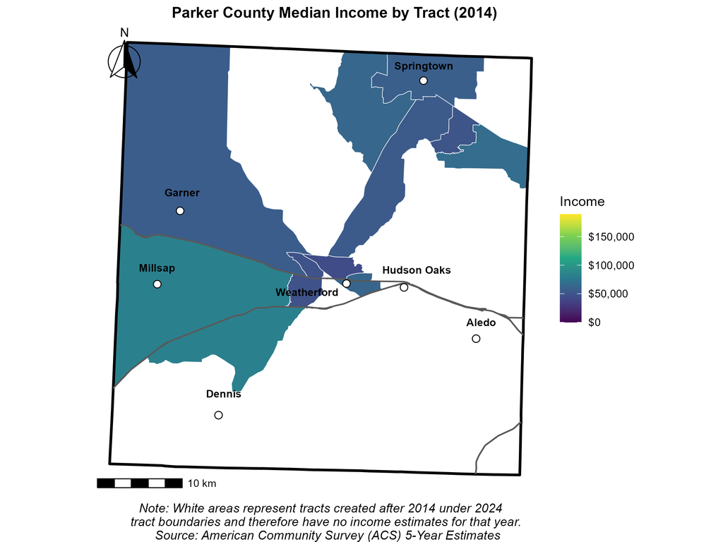

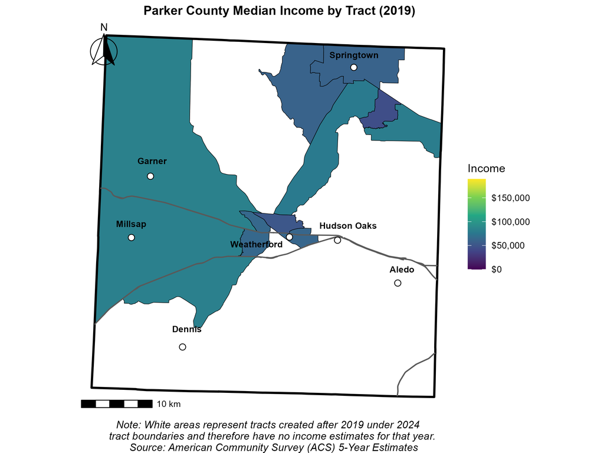

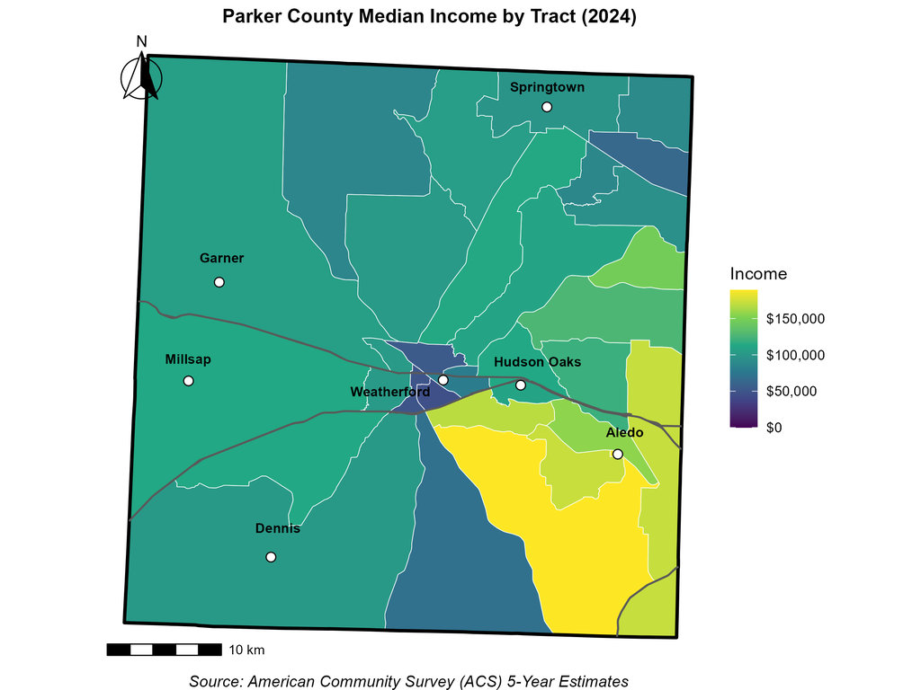

Median Household Income: 2014 vs. 2019 vs. 2024

[figure not shown]

[figure not shown]

```r
knitr::include_graphics(c("../outputs/map_income_2014.png",
                          "../outputs/map_income_2019.png",
                           "../outputs/map_income_2024.png"))
```

### Population Growth

##### These results suggest:

- Growth is not only increasing — it’s reshaping the county’s geography.
- Expansion is driven by suburban spillover.
- Infrastructure and housing demand are likely rising rapidly.

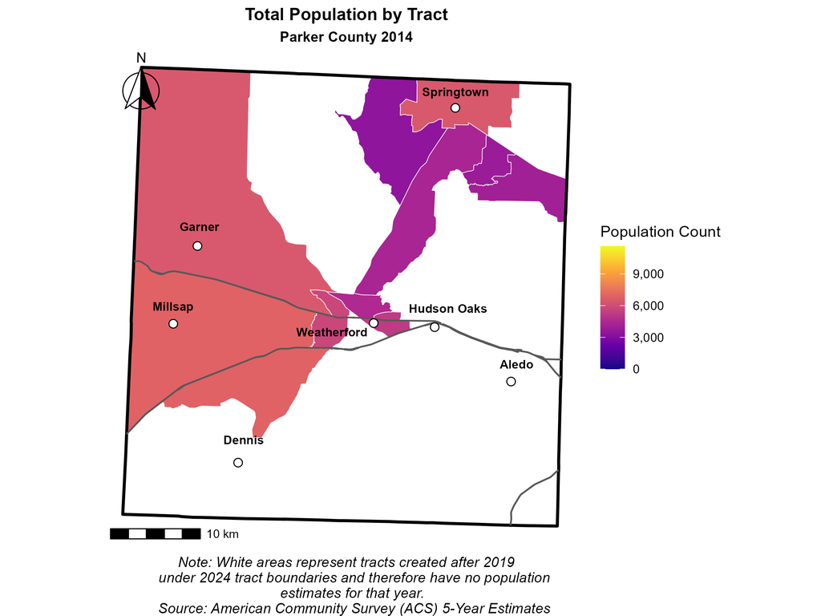

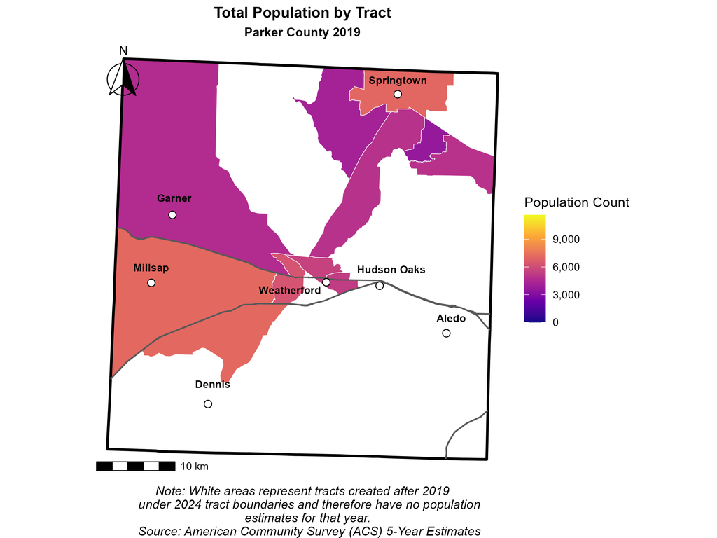

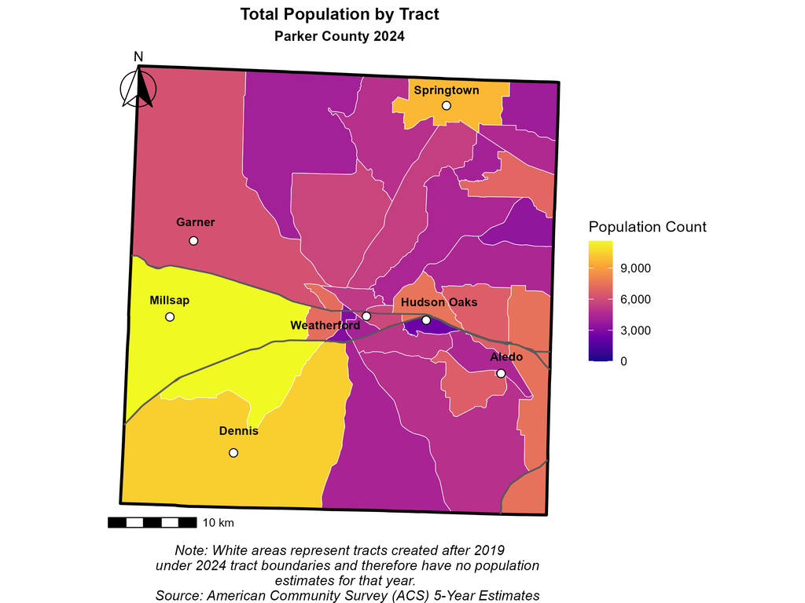

Population: 2014 vs. 2019 vs. 2024

```r
knitr::include_graphics(c("../outputs/map_pop_2014.png",
                          "../outputs/map_pop_2019.png",
                           "../outputs/map_pop_2024.png"))
```

### Demographic Shifts

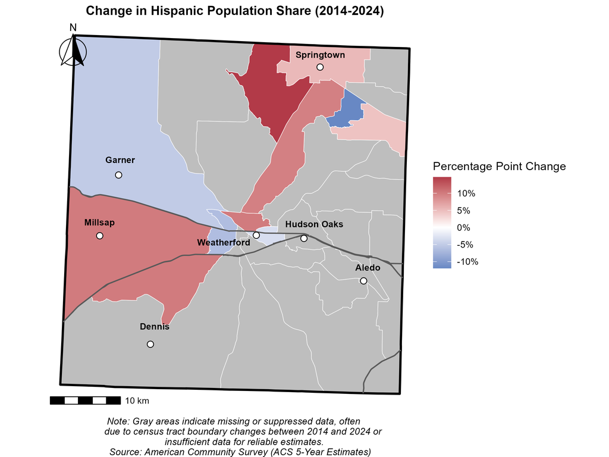

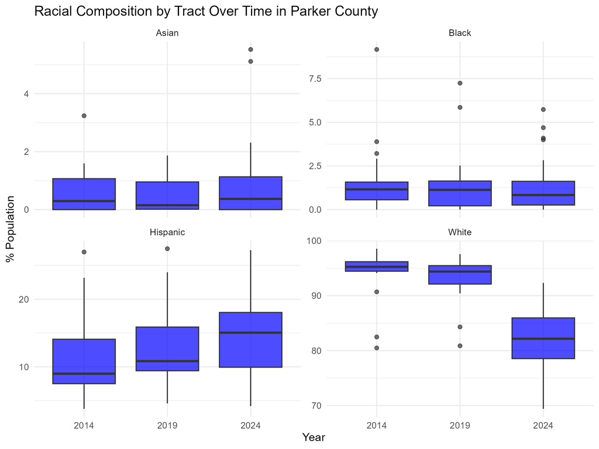

### Age Distribution Patterns

##### These results suggest:

- The population is gradually aging.
- Demand for healthcare and senior services will likely increase.
- Housing and infrastructure may need to adapt.
- Slower youth growth may impact future school enrollment.

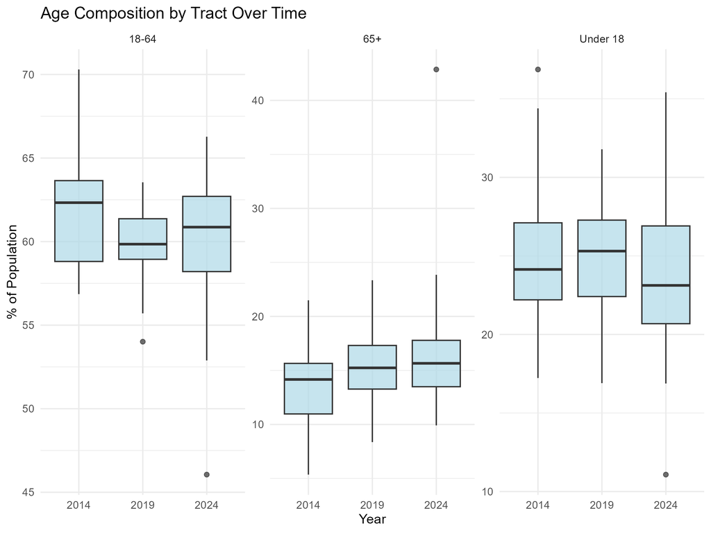

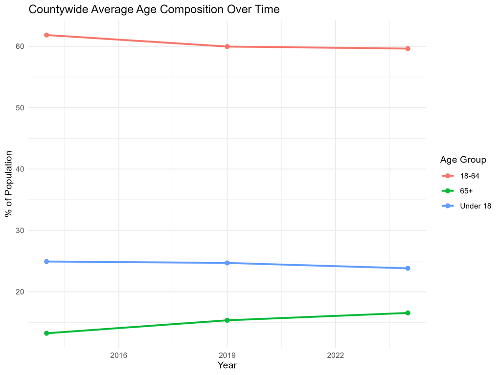

## 6. Limitations

- Census tract boundaries change over time; this analysis uses 2024 boundaries for consistency.
- ACS estimates include sampling error not explicitly modeled.
- Some tracts contain missing or suppressed data.

## 7. Conclusion

Parker County is undergoing significant demographic and economic transformation. Growth is uneven, inequality is increasing, and the population is becoming more diverse and older. These findings provide a foundation for understanding how suburban expansion is reshaping communities at the local level.

### Disclaimer

This product uses the Census Bureau Data API but is not endorsed or certified by the Census Bureau.

## References:

- https://www.census.gov/programs-surveys/acs/data/data-via-api.html
- https://www.parkercountyedc.com/news
- https://www.census.gov/data/developers/data-sets/acs-5year.html
- https://www.census.gov/geographies/mapping-files/time-series/geo/tiger-line-file.html
- https://fortworthreport.org/2024/08/18/fast-growing-parker-county-prepares-for-a-lot-more-change-with-arrival-of-uta-campus/#
- https://www.mckinsey.com/institute-for-economic-mobility/our-insights/small-towns-massive-opportunity-unlocking-rural-americas-potential
- https://trerc.tamu.edu/article/can-texas-sustain-its-growth/#
- https://www.fox26houston.com/news/texas-immigration-report-2025